# Investigating the Relation Between Industry Growth and Water Contamination

Lu Xiaoding Tom, Tobby Satyarama, Yang Ming, Theodoros Ouzounellis-Kavlakonis

November 3, 2018

# Summary

The recent developments in Flint County, Michigan have cast the nation-wide water situation into the public eye. While most areas in the United States have adequate access to clean water, municipal water supplies in some rural areas are contaminated to health-affecting levels. This poses significant problems to the general population who relies on easy access to municipal water for their every day needs.

While problems with water contamination sometimes occur due to improper storage and piping, frequently they are also caused by waste from businesses in the vicinity. The topic question we chose to ask ourselves is: **Within counties which are plagued by contaminated water, is the growth of any specific industries positively correlated to contamination levels of any specific contaminant?**

## Key findings

The financial/real estate industry was found as a whole to be significantly correlated to higher levels of haloacetic acids and trihalomethanes in nearby water sources. The retail and trade industry was also found to be significantly positively correlated the higher levels of haloacetic acids.

# Technical Exposition

## Data processing and initial exploration

The `chemicals.csv` dataset was processed to summarise the concentrations of each contaminant in excess of the safe concentrations of each contaminant (determined by the EPA) per community water system per year:

- 30 μ/L of Uranium
- 10 μ/L of Arsenic
- 6 μ/L of DEHP
- 10 mg/L of Nitrates, converted to 10,000 μ/L to standardise units
- 60 μ/L of Haloacetic Acids
- 80 μ/L of Trihalomethanes

The processed values are the proportion of the raw values in excess of the above values; a water system having 45μ/L of uranium would be processed as 0.5 in the dataset, for example. If the raw values were less than or equal to the safe levels, a value of 0 was inserted instead.

For each county (identified by FIPS number) and year, the average excess percentages were determined.

The `earnings.csv` dataset was also processed to summarise the *normalised relative growth* of each industry over the previous year, and the datasets were then inner-merged on county FIPS codes and year. For example, an industry that showed 4%, 5% and 6% growth in 2011 to 2013 in one county would subsequently be displayed as -0.01, 0 and 0.01 in the dataset. The normalisation was performed to eliminate county size as a factor; larger and more populated counties would naturally have faster-growing industries, and this would add noise when attempting to compare across counties.

The two datasets were then inner-merged on FIPS code and county to produce a dataset with the average excess concentrations of the 6 contaminants and the normalised relative growths of the 26 industries given, with each row corresponding to the statistics in one county in a year.

To narrow our scope to specifically counties that were chronically affected by impure water, any counties which consistently had uncontaminated water were subsequently removed from the dataset.

A correlation table was then made between the average excess contamination of the 6 contaminants and the 26 industries.

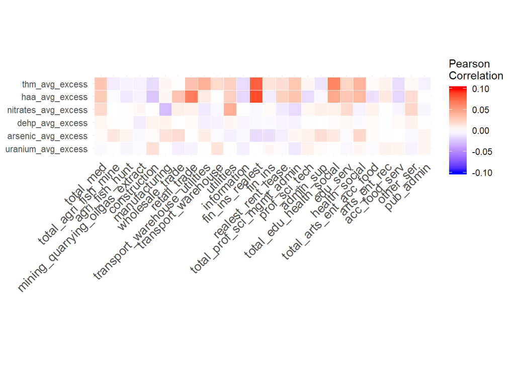

Of these, the particularly dark spots around the `fin_ins_realest` and `retail_trade` industries jumped out for further analysis.

## Building a model

A simple model to begin with when investigating the relationship between specific industry growth and contamination levels is a general linear model, since the percentages being worked with in these is small and modelling marginal changes is more feasible given that many possibly conflating variables exist for which data is lacking.

For the relationship between finance/insurance/real estate and haloacetic acid levels, we have:

```
##
## Call:
## glm(formula = haa_avg_excess ~ fin_ins_realest, data = dataset)
##
## Deviance Residuals:
##      Min        1Q    Median        3Q       Max
## -0.19251  -0.01502  -0.01282  -0.00938   2.43550
##
## Coefficients:
##                 Estimate Std. Error t value Pr(>|t|)
## (Intercept)     0.013574   0.001638   8.289  < 2e-16 ***
## fin_ins_realest 0.066923   0.012129   5.517 3.65e-08 ***
## ---
## Signif. codes:  0 '***' 0.001 '**' 0.01 '*' 0.05 '.' 0.1 ' ' 1
##
## (Dispersion parameter for gaussian family taken to be 0.01088532)
##
##     Null deviance: 44.493  on 4058  degrees of freedom
## Residual deviance: 44.162  on 4057  degrees of freedom
## AIC: -6825.1
##
## Number of Fisher Scoring iterations: 2
```

Under this model, we see that a **1% growth** in the earnings of the Finance/Insurance/Real Estate industry **above the average growth** is associated with an increase in haloacetic acid levels equal to **6.69% of the EPA recommended safe level, or 4.01μ/L**. The relationship, though weak, is quite certain, with a result this extreme having a **3.65x10<sup>-8</sup>** probability to occur under a null hypothesis of growth having no correlation with the HAA contamination levels.

For the relationship between the retail trade industry and HAA levels, we have:

```
##
## Call:
## glm(formula = haa_avg_excess ~ retail_trade, data = dataset)
##
## Deviance Residuals:
##      Min        1Q    Median        3Q       Max
## -0.11545  -0.01511  -0.01295  -0.00966   2.47398
##
## Coefficients:
##              Estimate Std. Error t value Pr(>|t|)
## (Intercept)   0.01357    0.00164   8.276  < 2e-16 ***
## retail_trade  0.06544    0.01558   4.201 2.71e-05 ***
## ---
## Signif. codes:  0 '***' 0.001 '**' 0.01 '*' 0.05 '.' 0.1 ' ' 1
##
## (Dispersion parameter for gaussian family taken to be 0.0109195)
##
##     Null deviance: 44.493  on 4058  degrees of freedom
## Residual deviance: 44.300  on 4057  degrees of freedom
## AIC: -6812.4
##
## Number of Fisher Scoring iterations: 2
```

For the relationship between the finance/insurance/real estate industry and trihalomethane levels, we have:

```
##
## Call:
## glm(formula = thm_avg_excess ~ fin_ins_realest, data = dataset)
##
## Deviance Residuals:
##      Min        1Q    Median        3Q       Max
## -0.12778  -0.01631  -0.01486  -0.01034   1.46389
##
## Coefficients:
##                 Estimate Std. Error t value Pr(>|t|)
## (Intercept)     0.015696   0.001140  13.764  < 2e-16 ***
## fin_ins_realest 0.041919   0.008447   4.963 7.24e-07 ***
## ---
## Signif. codes:  0 '***' 0.001 '**' 0.01 '*' 0.05 '.' 0.1 ' ' 1
##
## (Dispersion parameter for gaussian family taken to be 0.005279103)
##
##     Null deviance: 21.547  on 4058  degrees of freedom
## Residual deviance: 21.417  on 4057  degrees of freedom
## AIC: -9762.4
##
## Number of Fisher Scoring iterations: 2
```

## Visualisations

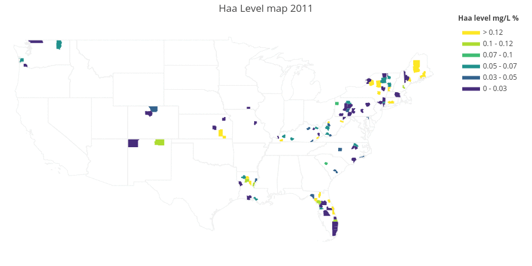

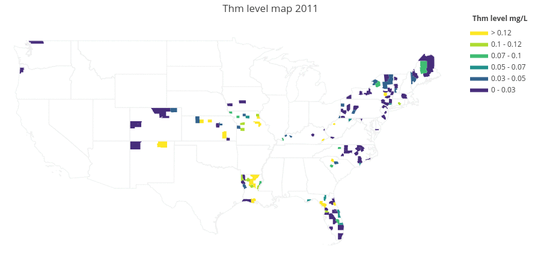